# Logistic Regression

Sarah Rameez

2024-11-17

# Logistic Regression

### Load the Libraries

```r
library(dplyr)
library(tidyr)
library(tidyverse)
```

```r
library(ggplot2)
library(lubridate)
library(stringr)
library(reshape2)
library(pscl)
library(caret)
library(effects)
library(car)
```

### Load the Data

```r
data <- read_csv('merged-data.csv')
```

## Descriptive Analysis

```r
# Select only numeric columns for analysis
numeric_data <- data[sapply(data, is.numeric)]

colSums(is.na(numeric_data))
```

```
##                  year                 month                   _id
##                     0                     0                     0
##       ORGANIZATION_ID            SHELTER_ID            PROGRAM_ID
##                     0                     0                     0
##    SERVICE_USER_COUNT   CAPACITY_ACTUAL_BED  CAPACITY_FUNDING_BED
##                     0                 56343                 56343
##         OCCUPIED_BEDS       UNOCCUPIED_BEDS      UNAVAILABLE_BEDS
##                 56343                 56343                 56343
##  CAPACITY_ACTUAL_ROOM CAPACITY_FUNDING_ROOM        OCCUPIED_ROOMS
##                117299                117486                117299
##      UNOCCUPIED_ROOMS     UNAVAILABLE_ROOMS   OCCUPANCY_RATE_BEDS
##                117299                117486                 56343
##  OCCUPANCY_RATE_ROOMS           LOCATION_ID               Assault
##                117299                     0                     0
##            Auto Theft            Theft Over               Robbery
##                     0                     0                     0
##       Break and Enter           total_crime      max_temp_celsius
##                     0                     0                  6555
##      min_temp_celsius             precip_cm               cpi_all
##                  6555                  1023                     0
##           cpi_shelter     unemployment_rate
##                     0                     0
```

```r
# Drop rows with missing values
#numeric_data_clean <- na.omit(numeric_data)
```

```r
# Summary Statistics Calculation
summary_stats <- data.frame(
  Mean = sapply(numeric_data, mean, na.rm = TRUE),
  Median = sapply(numeric_data, median, na.rm = TRUE),
  Std_Dev = sapply(numeric_data, sd, na.rm = TRUE),
  IQR = sapply(numeric_data, function(x) IQR(x, na.rm = TRUE))
)

# Display summary statistics
print(summary_stats)
```

```
##                               Mean    Median      Std_Dev       IQR
## year                  2.022335e+03  2022.000 1.066039e+00     2.000
## month                 6.107687e+00     6.000 3.369246e+00     6.000
## _id                   9.017764e+04 90078.500 5.206088e+04 90014.750
## ORGANIZATION_ID       1.382409e+01    13.000 1.091506e+01    21.000
## SHELTER_ID            3.590611e+01    33.000 2.458399e+01    37.000
## PROGRAM_ID            1.411186e+04 14251.000 1.871429e+03  3460.000
## SERVICE_USER_COUNT    6.099118e+01    39.000 7.650523e+01    49.000
## CAPACITY_ACTUAL_BED   3.975949e+01    30.000 3.551070e+01    31.000
## CAPACITY_FUNDING_BED  4.133485e+01    31.000 3.655972e+01    32.000
## OCCUPIED_BEDS         3.891021e+01    30.000 3.560123e+01    32.000
## UNOCCUPIED_BEDS       8.492826e-01     0.000 2.296561e+00     1.000
## UNAVAILABLE_BEDS      1.575359e+00     0.000 6.038958e+00     1.000
## CAPACITY_ACTUAL_ROOM  6.657840e+01    45.000 6.528583e+01    55.000
## CAPACITY_FUNDING_ROOM 6.688361e+01    43.000 6.740717e+01    59.000
## OCCUPIED_ROOMS        6.583297e+01    45.000 6.498532e+01    55.000
## UNOCCUPIED_ROOMS      7.454342e-01     0.000 2.837523e+00     0.000
## UNAVAILABLE_ROOMS     4.878927e+00     1.000 1.062598e+01     5.000
## OCCUPANCY_RATE_BEDS   9.617246e+01   100.000 9.306506e+00     2.700
## OCCUPANCY_RATE_ROOMS  9.812314e+01   100.000 6.235630e+00     0.000
## LOCATION_ID           1.104183e+03  1103.000 8.147102e+01   116.000
## Assault               8.734811e-01     0.000 1.239018e+00     1.000
## Auto Theft            1.935419e-01     0.000 5.813181e-01     0.000
## Theft Over            5.112242e-02     0.000 2.316912e-01     0.000
## Robbery               1.081536e-01     0.000 4.142052e-01     0.000
## Break and Enter       2.217897e-01     0.000 5.127614e-01     0.000
## total_crime           1.448089e+00     1.000 1.632725e+00     2.000
## max_temp_celsius      1.411060e+01    14.100 1.051830e+01    19.000
## min_temp_celsius      6.448245e+00     6.300 9.413675e+00    15.400
## precip_cm             2.280470e-01     0.000 6.420865e-01     0.130
## cpi_all               1.546001e+02   155.900 7.655809e+00    14.600
## cpi_shelter           1.697645e+02   169.100 1.096949e+01    19.700
## unemployment_rate     7.350865e-02     0.071 1.404589e-02     0.018
```

```r
# Summary Statistics Calculation
summary_stats <- data.frame(
  Mean = sapply(numeric_data, mean, na.rm = TRUE),
  Median = sapply(numeric_data, median, na.rm = TRUE),
  Std_Dev = sapply(numeric_data, sd, na.rm = TRUE),
  IQR = sapply(numeric_data, function(x) IQR(x, na.rm = TRUE))
)
```

### Keep only selected variables:

- Availability total (dependent variable) - present limitation in paper
- Capacity
- Sector
- Hood_158 (Neighbourhood)
- Total Crime
- CPI_All
- Unemployment Rate
- Minimum Temperature
- Precipitation (cm)

#### Create total capacity and occupancy

Since we have two kinds of capacities - Room-based and Bed-based, we need to either delete one or the other category, or determine the number of beds per room and apply them to each room-based shelter.

First, we will determine the distribution of rooms and bed-based capacities:

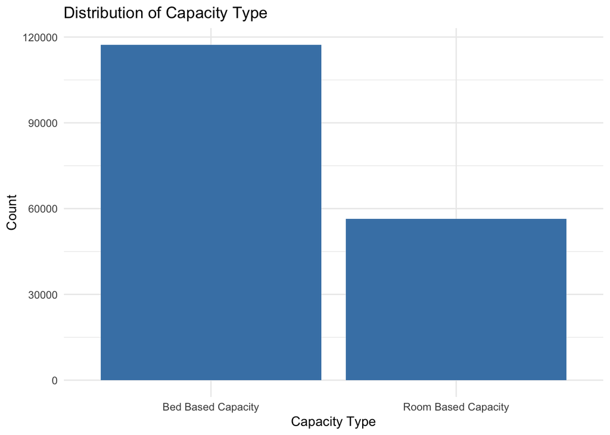

```r
ggplot(data, aes(x = as.factor(CAPACITY_TYPE))) +
  geom_bar(fill = "steelblue") +
  labs(
    title = "Distribution of Capacity Type",
    x = "Capacity Type",
    y = "Count"
  ) +
  theme_minimal()
```

```r
prop_table <- prop.table(table(data$CAPACITY_TYPE))

print(prop_table)
```

```
##
##  Bed Based Capacity Room Based Capacity
##           0.6755221           0.3244779
```

Given Room-based capacities make up roughly 32% of the data, we cannot remove it completely without significantly skewing our analysis.

We therefore reached out to all room-based shelters and requested them to provide the number of beds per room, out of which 8 shelters were able to provide the data

```r
shelter_info <- data %>%
  filter(CAPACITY_TYPE == 'Room Based Capacity') %>%
  select(SHELTER_ID, ORGANIZATION_NAME, CAPACITY_TYPE, CAPACITY_ACTUAL_ROOM, LOCATION_NAME, LOCATION_ADDRESS, LOCATION_POSTAL_CODE) %>%
  distinct(SHELTER_ID, .keep_all = TRUE)

unique(shelter_info$ORGANIZATION_NAME)
```

```
##  [1] "City of Toronto"
##  [2] "Eva's Initiatives"
##  [3] "The Salvation Army of Canada"
##  [4] "Homes First Society"
##  [5] "Kennedy House Youth Services"
##  [6] "COSTI Immigrant Services"
##  [7] "Fred Victor Centre"
##  [8] "YWCA Toronto"
##  [9] "WoodGreen Red Door Family Shelter"
## [10] "St. Simon's Shelter Inc."
## [11] "The MUC Shelter Corporation"
## [12] "Street Haven At The Crossroads"
## [13] "Good Shepherd Ministries"
## [14] "Dixon Hall"
## [15] "YMCA of Greater Toronto"
## [16] "Covenant House Toronto"
## [17] "Toronto Community Hostel"
## [18] "Native Child & Family Services Toronto"
## [19] "Christie Refugee Welcome Centre, Inc."
## [20] "Christie Ossington Neighbourhood Centre"
## [21] "The Canadian Red Cross Society"
```

```r
# load the manually inserted data
shelter_rooms <- read_csv('raw-data/shelter-room-beds.csv')
shelter_rooms_mean <- mean(shelter_rooms$`Beds per room`, na.rm = TRUE)
```

Now that we have the average number of rooms, we apply it to the dataframe for all room-based capacity types:

```r
# replace NA values with 0 for room based capacity and occupancy
data <- data %>%
  mutate(
    CAPACITY_ACTUAL_ROOM = ceiling(replace(CAPACITY_ACTUAL_ROOM, is.na(CAPACITY_ACTUAL_ROOM), 0) * shelter_rooms_mean),
    OCCUPIED_ROOMS = ceiling(replace(OCCUPIED_ROOMS, is.na(OCCUPIED_ROOMS), 0) * shelter_rooms_mean),
    UNOCCUPIED_ROOMS = ceiling(replace(UNOCCUPIED_ROOMS, is.na(UNOCCUPIED_ROOMS), 0 * shelter_rooms_mean))
  )
```

```r
# combine the updated capacities and occupancies
data_filtered <- data %>%
  mutate(
    capacity_total = replace_na(CAPACITY_ACTUAL_BED, 0) + replace_na(CAPACITY_ACTUAL_ROOM, 0),
    occupied_total = replace_na(OCCUPIED_BEDS, 0) + replace_na(OCCUPIED_ROOMS, 0),
    availability_total = replace_na(UNOCCUPIED_BEDS, 0) + replace_na(UNOCCUPIED_ROOMS, 0),
    available_binary = if_else(availability_total > 0, 1, 0),
    availability_rate = availability_total / capacity_total
  )
```

#### Remove unnecessary variables

```r
data_relevant <- data_filtered %>%
  select(c(date, available_binary, availability_total, availability_rate, capacity_total, SECTOR, HOOD_158, total_crime, cpi_all, unemployment_rate, min_temp_celsius, precip_cm)) %>%
  rename(neighbourhood = HOOD_158,
         sector = SECTOR)
```